# Requirements

- Change the file name to yourlastname_firstinitial_HW_Pandas_for_TextAnalytics
- import **smallsample_tweet_from_azuredatafactory.csv** and complete all the cells below. If necessary, you can create more cells.
- Change the filename to **yourlastname_firstinitial_HW_Pandas_for_TextAnalytics**
- Use **df.head()**, not df

Brian Kassin **"K-State Honor Code "On my honor, as a student, I have neither given nor received unauthorized aid on this academic work.**

```python
import pandas as pd
import csv
import re
from textblob import TextBlob      #if not done already, you need to install textblob
```

```python
pd.set_option('display.max_colwidth', -1)
```

Import data and display five rows

```python
df = pd.read_csv('data/smallsample_tweet_from_azuredatafactory.csv', encoding = "ISO-8859-1")
df.head()
```

|  | tweet |
| --- | --- |
| 0 | This development is pretty exciting for me #supplychain #sustainability |
| 1 | Samsung assures excellent working conditions in China http://t.<br>co/9VcBIL1XAj #workingconditions #supplychain #responsiblesourcing #rtw |
| 2 | Loving the feedback that I am getting on this report today! #supplychain http://t.<br>co/7DJaJFFl |
| 3 | As parked 787s multiply? Boeing cash drain worries grow ... the future could be worse ... http://t.<br>co/up6V9sBYbi #supplychain |
| 4 | CHaINA Magazine: Apple Finds Child Labor Abuses in Its Supply Chain - As the controversy regarding. the situation is very bad ... http://t.<br>co/kt6MMXvng #SupplyChain |

Find out data types and number of rows in the dataset

```python
total_tweets = len(df)
print(total_tweets)
```

```
4514
```

```python
df.describe()
```

|  | tweet |
| --- | --- |
| count | 4514 |
| unique | 392 |
| top | @pier1 has signed a lease for a new 8,750 SF store at Blackmore Marketplace in Casper, WY!!! #CRE #retail |
| freq | 179 |

```python
df.info()
```

```
<class 'pandas.core.frame.DataFrame'>
RangeIndex: 4514 entries, 0 to 4513
Data columns (total 1 columns):
tweet    4514 non-null object
dtypes: object(1)
memory usage: 35.3+ KB
```

```python
df.dtypes
```

```
tweet    object
dtype: object
```

## Below, you need to transform / clean / analyse the tweets.

- You can use more than one cell to respond to each requirement.
- After data transformation/cleaning/analysis, make sure to update the data (df)
- Display the first five rows after each data transformation/cleaning/analysis

### Data transformation & exploratory data analysis

Lowercase words (you need to **update** your data --> the tweets need to be lowercased)

```python
df['tweet'] = df['tweet'].str.lower()
df.head()
```

|  | tweet |
| --- | --- |
| 0 | this development is pretty exciting for me #supplychain #sustainability |
| 1 | samsung assures excellent working conditions in china http://t.<br>co/9vcbil1xaj #workingconditions #supplychain #responsiblesourcing #rtw |
| 2 | loving the feedback that i am getting on this report today! #supplychain http://t.<br>co/7djajffl |
| 3 | as parked 787s multiply? boeing cash drain worries grow ... the future could be worse ... http://t.<br>co/up6v9sbybi #supplychain |
| 4 | chaina magazine: apple finds child labor abuses in its supply chain - as the controversy regarding. the situation is very bad ... http://t.<br>co/kt6mmxvng #supplychain |

Create a column "retweet" and show "True" if tweet is retweet

```python
df['retweet'] = df.tweet.str.startswith("rt")
df.head()
```

|  | tweet | retweet |
| --- | --- | --- |
| 0 | this development is pretty exciting for me #supplychain #sustainability | False |
| 1 | samsung assures excellent working conditions in china http://t.<br>co/9vcbil1xaj #workingconditions #supplychain #responsiblesourcing #rtw | False |
| 2 | loving the feedback that i am getting on this report today! #supplychain http://t.<br>co/7djajffl | False |
| 3 | as parked 787s multiply? boeing cash drain worries grow ... the future could be worse ... http://t.<br>co/up6v9sbybi #supplychain | False |
| 4 | chaina magazine: apple finds child labor abuses in its supply chain - as the controversy regarding. the situation is very bad ... http://t.<br>co/kt6mmxvng #supplychain | False |

```python
df['retweet'] = df.tweet.str.startswith("rt").astype('str')
```

```python
df.dtypes
```

```
tweet      object
retweet    object
dtype: object
```

Find out how many reweets and how many original tweets in the data and display the analysis results below

```python
df.groupby('retweet').count()
```

| retweet | tweet |
| --- | --- |
| False | 3450 |
| True | 1064 |

```python
retweets = df.tweet.str.contains("^rt")
df[retweets].count()
```

```
tweet      1064
retweet    1064
dtype: int64
```

Show the percentage of "retweets" in the data and display the result below

```python
df.groupby('retweet').size()['True'] / total_tweets
```

```
0.2357111209570226
```

```python
percent_rt = df[retweets].count() / total_tweets
print(percent_rt)
```

```
tweet      0.235711
retweet    0.235711
dtype: float64
```

Find out the number of characters in each tweet and create a column "counts"

```python
df['counts'] = df['tweet'].str.len()
df.head()
```

|  | tweet | retweet | counts |
| --- | --- | --- | --- |
| 0 | this development is pretty exciting for me #supplychain #sustainability | False | 71 |
| 1 | samsung assures excellent working conditions in china http://t.<br>co/9vcbil1xaj #workingconditions #supplychain #responsiblesourcing #rtw | False | 138 |
| 2 | loving the feedback that i am getting on this report today! #supplychain http://t.<br>co/7djajffl | False | 97 |
| 3 | as parked 787s multiply? boeing cash drain worries grow ... the future could be worse ... http://t.<br>co/up6v9sbybi #supplychain | False | 133 |
| 4 | chaina magazine: apple finds child labor abuses in its supply chain - as the controversy regarding. the situation is very bad ... http://t.<br>co/kt6mmxvng #supplychain | False | 169 |

Find out the number of words in each tweet and create a column "wordcount"

```python
df['wordcount'] = df['tweet'].str.split().str.len()
df.head()
```

|  | tweet | retweet | counts | wordcount |
| --- | --- | --- | --- | --- |
| 0 | this development is pretty exciting for me #supplychain #sustainability | False | 71 | 9 |
| 1 | samsung assures excellent working conditions in china http://t.<br>co/9vcbil1xaj #workingconditions #supplychain #responsiblesourcing #rtw | False | 138 | 12 |
| 2 | loving the feedback that i am getting on this report today! #supplychain http://t.<br>co/7djajffl | False | 97 | 13 |
| 3 | as parked 787s multiply? boeing cash drain worries grow ... the future could be worse ... http://t.<br>co/up6v9sbybi #supplychain | False | 133 | 18 |
| 4 | chaina magazine: apple finds child labor abuses in its supply chain - as the controversy regarding. the situation is very bad ... http://t.<br>co/kt6mmxvng #supplychain | False | 169 | 24 |

Find the average word length and create a column "avgwordlen"

```python
df['avgwordlen'] = df['counts'] / df['wordcount']
df.head()
```

|  | tweet | retweet | counts | wordcount | avgwordlen |
| --- | --- | --- | --- | --- | --- |
| 0 | this development is pretty exciting for me #supplychain #sustainability | False | 71 | 9 | 7.888889 |
| 1 | samsung assures excellent working conditions in china http://t.<br>co/9vcbil1xaj #workingconditions #supplychain #responsiblesourcing #rtw | False | 138 | 12 | 11.500000 |
| 2 | loving the feedback that i am getting on this report today! #supplychain http://t.<br>co/7djajffl | False | 97 | 13 | 7.461538 |
| 3 | as parked 787s multiply? boeing cash drain worries grow ... the future could be worse ... http://t.<br>co/up6v9sbybi #supplychain | False | 133 | 18 | 7.388889 |
| 4 | chaina magazine: apple finds child labor abuses in its supply chain - as the controversy regarding. the situation is very bad ... http://t.<br>co/kt6mmxvng #supplychain | False | 169 | 24 | 7.041667 |

Find the overall aveage of word length and display below

```python
df['avgwordlen'].mean()
```

```
7.535228111198761
```

Find hashtags and creat a column "hash"

```python
df['hash'] = df.tweet.str.findall("(?<=#)\w+")
df.head()
```

|  | tweet | retweet | counts | wordcount | avgwordlen | hash |
| --- | --- | --- | --- | --- | --- | --- |
| 0 | this development is pretty exciting for me #supplychain #sustainability | False | 71 | 9 | 7.888889 | [supplychain, sustainability] |
| 1 | samsung assures excellent working conditions in china http://t.<br>co/9vcbil1xaj #workingconditions #supplychain #responsiblesourcing #rtw | False | 138 | 12 | 11.500000 | [workingconditions, supplychain, responsiblesourcing, rtw] |
| 2 | loving the feedback that i am getting on this report today! #supplychain http://t.<br>co/7djajffl | False | 97 | 13 | 7.461538 | [supplychain] |
| 3 | as parked 787s multiply? boeing cash drain worries grow ... the future could be worse ... http://t.<br>co/up6v9sbybi #supplychain | False | 133 | 18 | 7.388889 | [supplychain] |
| 4 | chaina magazine: apple finds child labor abuses in its supply chain - as the controversy regarding. the situation is very bad ... http://t.<br>co/kt6mmxvng #supplychain | False | 169 | 24 | 7.041667 | [supplychain] |

Find the average number of hashtags per tweet and display it below

```python
df['hash'].str.len().mean()
```

```
0.7233052724856004
```

Find Twitter mentions (e.g., @cnn, @kstate_cba) and create a column "mentions"

```python
df['mentions'] = df.tweet.str.findall("(?<=@)\w+")
df.head()
```

|  | tweet | retweet | counts | wordcount | avgwordlen | hash | mentions |
| --- | --- | --- | --- | --- | --- | --- | --- |
| 0 | this development is pretty exciting for me #supplychain #sustainability | False | 71 | 9 | 7.888889 | [supplychain, sustainability] | [] |
| 1 | samsung assures excellent working conditions in china http://t.<br>co/9vcbil1xaj #workingconditions #supplychain #responsiblesourcing #rtw | False | 138 | 12 | 11.500000 | [workingconditions, supplychain, responsiblesourcing, rtw] | [] |
| 2 | loving the feedback that i am getting on this report today! #supplychain http://t.<br>co/7djajffl | False | 97 | 13 | 7.461538 | [supplychain] | [] |
| 3 | as parked 787s multiply? boeing cash drain worries grow ... the future could be worse ... http://t.<br>co/up6v9sbybi #supplychain | False | 133 | 18 | 7.388889 | [supplychain] | [] |
| 4 | chaina magazine: apple finds child labor abuses in its supply chain - as the controversy regarding. the situation is very bad ... http://t.<br>co/kt6mmxvng #supplychain | False | 169 | 24 | 7.041667 | [supplychain] | [] |

Find the average number of mentions per tweet and display it below

```python
df['mentions'].str.len().mean()
```

```
0.924235711120957
```

Find out how many tweets contain the word "store" and display the analysis result

```python
store = df.tweet.str.contains("store")
df[store].head()
```

|  | tweet | retweet | counts | wordcount | avgwordlen | hash | mentions |
| --- | --- | --- | --- | --- | --- | --- | --- |
| 28 | never shopping @pier1 again! attempted a return &amp; didn't have a receipt sku/price tag was attached i was denied even in-store credit #fail | False | 142 | 23 | 6.173913 | [fail] | [pier1] |
| 110 | amazing view behind the #pier1 store. http://t.co/6xonkh8tfk | False | 60 | 7 | 8.571429 | [pier1] | [] |
| 157 | @yungwizzz i saw that fool yesterday at pier1...or whatever that little store is | False | 80 | 13 | 6.153846 | [] | [yungwizzz] |
| 203 | love love love this store. i can buy everything ?? @pier1 http://t.co/1uop3qyar9 | False | 80 | 12 | 6.666667 | [] | [pier1] |
| 262 | the lack of functionality of canadian websites for large stores...is embarrassing. guess they don't really want our money! @pier1 @target | False | 137 | 20 | 6.850000 | [] | [pier1, target] |

```python
df[store].count()
```

```
tweet         347
retweet       347
counts        347
wordcount     347
avgwordlen    347
hash          347
mentions      347
dtype: int64
```

### Text cleaning

Remove numbers in tweets and update the column

```python
df['tweet'].str.replace('\d+', '')
df.head()
```

|  | tweet | retweet | counts | wordcount | avgwordlen | hash | mentions |
| --- | --- | --- | --- | --- | --- | --- | --- |
| 0 | this development is pretty exciting for me #supplychain #sustainability | False | 71 | 9 | 7.888889 | [supplychain, sustainability] | [] |
| 1 | samsung assures excellent working conditions in china http://t.<br>co/9vcbil1xaj #workingconditions #supplychain #responsiblesourcing #rtw | False | 138 | 12 | 11.500000 | [workingconditions, supplychain, responsiblesourcing, rtw] | [] |
| 2 | loving the feedback that i am getting on this report today! #supplychain http://t.<br>co/7djajffl | False | 97 | 13 | 7.461538 | [supplychain] | [] |
| 3 | as parked 787s multiply? boeing cash drain worries grow ... the future could be worse ... http://t.<br>co/up6v9sbybi #supplychain | False | 133 | 18 | 7.388889 | [supplychain] | [] |
| 4 | chaina magazine: apple finds child labor abuses in its supply chain - as the controversy regarding. the situation is very bad ... http://t.<br>co/kt6mmxvng #supplychain | False | 169 | 24 | 7.041667 | [supplychain] | [] |

Remove urls and the update the column

```python
df['tweet'].str.replace(r'(http\S+|www.\S+)', ' ')
df.head()
```

|  | tweet | retweet | counts | wordcount | avgwordlen | hash | mentions |
| --- | --- | --- | --- | --- | --- | --- | --- |
| 0 | this development is pretty exciting for me #supplychain #sustainability | False | 71 | 9 | 7.888889 | [supplychain, sustainability] | [] |
| 1 | samsung assures excellent working conditions in china http://t.<br>co/9vcbil1xaj #workingconditions #supplychain #responsiblesourcing #rtw | False | 138 | 12 | 11.500000 | [workingconditions, supplychain, responsiblesourcing, rtw] | [] |
| 2 | loving the feedback that i am getting on this report today! #supplychain http://t.<br>co/7djajffl | False | 97 | 13 | 7.461538 | [supplychain] | [] |
| 3 | as parked 787s multiply? boeing cash drain worries grow ... the future could be worse ... http://t.<br>co/up6v9sbybi #supplychain | False | 133 | 18 | 7.388889 | [supplychain] | [] |
| 4 | chaina magazine: apple finds child labor abuses in its supply chain - as the controversy regarding. the situation is very bad ... http://t.<br>co/kt6mmxvng #supplychain | False | 169 | 24 | 7.041667 | [supplychain] | [] |

Remove non-alphabetic words & characters and update the column

```python
df['tweet'].str.replace('[^a-zA-Z0-9]+', ' ')
df.head()
```

|  | tweet | retweet | counts | wordcount | avgwordlen | hash | mentions |
| --- | --- | --- | --- | --- | --- | --- | --- |
| 0 | this development is pretty exciting for me #supplychain #sustainability | False | 71 | 9 | 7.888889 | [supplychain, sustainability] | [] |
| 1 | samsung assures excellent working conditions in china http://t.<br>co/9vcbil1xaj #workingconditions #supplychain #responsiblesourcing #rtw | False | 138 | 12 | 11.500000 | [workingconditions, supplychain, responsiblesourcing, rtw] | [] |
| 2 | loving the feedback that i am getting on this report today! #supplychain http://t.<br>co/7djajffl | False | 97 | 13 | 7.461538 | [supplychain] | [] |
| 3 | as parked 787s multiply? boeing cash drain worries grow ... the future could be worse ... http://t.<br>co/up6v9sbybi #supplychain | False | 133 | 18 | 7.388889 | [supplychain] | [] |
| 4 | chaina magazine: apple finds child labor abuses in its supply chain - as the controversy regarding. the situation is very bad ... http://t.<br>co/kt6mmxvng #supplychain | False | 169 | 24 | 7.041667 | [supplychain] | [] |

Remove short words (< 3) and update the column

```python
df['tweet'].str.findall('\w{3,}').str.join(' ')
df.head()
```

|  | tweet | retweet | counts | wordcount | avgwordlen | hash | mentions |
| --- | --- | --- | --- | --- | --- | --- | --- |
| 0 | this development is pretty exciting for me #supplychain #sustainability | False | 71 | 9 | 7.888889 | [supplychain, sustainability] | [] |
| 1 | samsung assures excellent working conditions in china http://t.<br>co/9vcbil1xaj #workingconditions #supplychain #responsiblesourcing #rtw | False | 138 | 12 | 11.500000 | [workingconditions, supplychain, responsiblesourcing, rtw] | [] |
| 2 | loving the feedback that i am getting on this report today! #supplychain http://t.<br>co/7djajffl | False | 97 | 13 | 7.461538 | [supplychain] | [] |
| 3 | as parked 787s multiply? boeing cash drain worries grow ... the future could be worse ... http://t.<br>co/up6v9sbybi #supplychain | False | 133 | 18 | 7.388889 | [supplychain] | [] |
| 4 | chaina magazine: apple finds child labor abuses in its supply chain - as the controversy regarding. the situation is very bad ... http://t.<br>co/kt6mmxvng #supplychain | False | 169 | 24 | 7.041667 | [supplychain] | [] |

Remove stopwords and update the column

```python
from nltk.corpus import stopwords
stopwords = stopwords.words('english')
```

```python
df['tweet'].apply(lambda x: ' '.join([word for word in x.split() if word not in (stopwords)]))
```

```
0       development pretty exciting #supplychain #sustainability
1       samsung assures excellent working conditions china http://t.<br>co/9vcbil1xaj #workingconditions #supplychain #responsiblesourcing #rtw
2       loving feedback getting report today! #supplychain http://t.<br>co/7djajffl
3       parked 787s multiply? boeing cash drain worries grow ... future could worse ... http://t.<br>co/up6v9sbybi #supplychain
4       chaina magazine: apple finds child labor abuses supply chain - controversy regarding. situation bad ... http://t.<br>co/kt6mmxvng #supplychain
5       walmart us chief says sales suffering restocking issues bad sales http://t.<br>co/xhpk4pyy3v #supplychain
6       climate change getting worse ... serious issue near time ...
7       forgot much love people job #pier1 #forever
8       need get #pier1. look cute #halloween #homedecor! #decorations #musthave http://t.co/k7yywgnasa
9       http://t.co/zmhc2omplq bedroom set still backorder, getting next week. ??
10      pier 1 imports fall tv advert moderately pretentious, gets top marks quality soundtrack. http://t.co/5ldy9kmx4h @pier1
11      @pier1: animals harmed making faux fur throws http://t.co/9b4ld3nc9z http://t.co/vm0820ugue luxury live w!
12      @pier1: meal lift spirits &amp; bright, inviting dining room http://t.co/3kr7mpxzsv http://t.co/xdnjieftjz perfect colors!
13      #halloween creepy candy caldron ready thanks #biglots #pier1 #joann #trickortreat http://t.co/gbtfgtnohg
14      u find use it, pier1 sale. http://t.co/zocbkihfia
```

[output cut: 47 more lines]

Do lemmatization and update the column

```python
# import nltk (natural language tool kit), a popular python package for text mining
import nltk
# stopwords, FreqDist, word_tokenize
from nltk.corpus import stopwords
from nltk import FreqDist, word_tokenize
from nltk.stem.porter import PorterStemmer
from nltk.stem import WordNetLemmatizer
from nltk.corpus import stopwords
#regular expression
import re
#csv
import csv
# Excel-like format
import pandas as pd
#data visualization
import matplotlib.pyplot as plt
%matplotlib inline
```

```python
#get stemming words or lemmas
wordnet_lemmatizer = WordNetLemmatizer()
df['tweet'] = df.tweet.apply(lambda x: ' '.join([wordnet_lemmatizer.lemmatize(word) for word in x.split()]))
```

### Descriptive text analytics

Create a word cloud

```python
from wordcloud import WordCloud, STOPWORDS
import matplotlib.pyplot as plt
%matplotlib inline
```

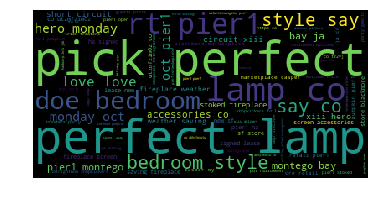

```python
wordcloud = WordCloud().generate(' '. join(df['tweet']))
plt.imshow(wordcloud)
plt.axis("off")
plt.show()
```

Display top 10 words in the data

```python
review = []
openfile = open('data/smallsample_tweet_from_azuredatafactory.csv', 'r')
r = csv.reader(openfile)
for i in r:
# get the first column only (ignoring the second column)
    review.append(i)
openfile.close()

# what if you have additional stopwords to be removed
tokens = str(review)
#lowecases
tokens = tokens.lower()
# Remove useless numbers and alphanumerical words
tokens = re.sub("[^a-zA-Z0-9]", " ", tokens)
#tokenization or word split
tokens = word_tokenize(tokens)
#get stemming words or lemmas
wordnet_lemmatizer = WordNetLemmatizer()
tokens = (wordnet_lemmatizer.lemmatize(word) for word in tokens)
#additional stopwrods
more_stopwords = set(('cant', 'aint', 'today'))
extra_stoplist = set(stopwords.words('english')) | more_stopwords
tokens = (word for word in tokens if word not in extra_stoplist)
# Filter non-alphanumeric characters from tokens
tokens = (word for word in tokens if word.isalpha())
#remove short words
tokens = (word for word in tokens if len(word) >= 3)

fdist = nltk.FreqDist(tokens)
fdist
```

```
FreqDist({'http': 4132, 'bedroom': 514, 'pick': 512, 'perfect': 508, 'lamp': 507, 'say': 469, 'style': 469, 'doe': 468, 'love': 448, 'amp': 412, ...})
```

```python
fdist.most_common(10)
```

```
[('http', 4132),
 ('bedroom', 514),
 ('pick', 512),
 ('perfect', 508),
 ('lamp', 507),
 ('say', 469),
 ('style', 469),
 ('doe', 468),
 ('love', 448),
 ('amp', 412)]
```

### Sentiment analysis

Show the results of sentiment analysis (Using **vaderSentiment**). I would be interested in how many positive / negative tweets are in the data. Create a column containing sentiment score.

```python
from nltk.sentiment.vader import SentimentIntensityAnalyzer
```

```python
analyzer = SentimentIntensityAnalyzer()

for sentence in df['tweet']:
    vs = analyzer.polarity_scores(sentence)
    print(vs["compound"])
```

[output not shown]

[output cut: 4459 more lines]

[output not shown]

```python
df['score'] = df['tweet'].apply(lambda x: analyzer.polarity_scores(x)['compound'])
df.head()
```

|  | tweet | retweet | counts | wordcount | avgwordlen | hash | mentions | score |
| --- | --- | --- | --- | --- | --- | --- | --- | --- |
| 0 | this development is pretty exciting for me #supplychain #sustainability | False | 71 | 9 | 7.888889 | [supplychain, sustainability] | [] | 0.7506 |
| 1 | samsung assures excellent working condition in china http://t.<br>co/9vcbil1xaj #workingconditions #supplychain #responsiblesourcing #rtw | False | 138 | 12 | 11.500000 | [workingconditions, supplychain, responsiblesourcing, rtw] | [] | 0.7184 |
| 2 | loving the feedback that i am getting on this report today! #supplychain http://t.<br>co/7djajffl | False | 97 | 13 | 7.461538 | [supplychain] | [] | 0.6360 |
| 3 | a parked 787s multiply? boeing cash drain worry grow ... the future could be worse ... http://t.<br>co/up6v9sbybi #supplychain | False | 133 | 18 | 7.388889 | [supplychain] | [] | -0.7184 |
| 4 | chaina magazine: apple find child labor abuse in it supply chain - a the controversy regarding. the situation is very bad ... http://t.<br>co/kt6mmxvng #supplychain | False | 169 | 24 | 7.041667 | [supplychain] | [] | -0.8399 |

Visit https://stackoverflow.com/questions/42907842/pandas-count-positive-negative-neutral-values and adapt the solution. If you choose to take a different approach, that would be just fine too.

How many positive / negative / neutral tweets?

```python
from textblob import TextBlob
```

```python
avg = []

for row in df['tweet']:
    avg.append([TextBlob(row).sentiment.polarity])

avg[:10]
```

```
[[0.275],
 [1.0],
 [0.75],
 [-0.13333333333333333],
 [-0.9099999999999998],
 [-0.6999999999999998],
 [-0.21111111111111114],
 [0.5],
 [0.625],
 [0.0]]
```

```python
positive_review = []
negative_review = []
neutral_review = []

for row in df['tweet']:
    #tweet = row[0]
    score = TextBlob(row).sentiment.polarity
    if score > 0:
        positive_review.append(row)
    elif score == 0:
        neutral_review.append(row)
    else:
        negative_review.append(row)
```

```python
print(len(positive_review))
print(len(negative_review))
print(len(neutral_review))
```

```
1983
120
2411
```

What is the overall sentiment in the data? Average sentiment score

```python
df['score'].mean()
```

```
0.2590651085511738
```

How do you like this HW?

C

- A ^-^
- B
- C
- D
- F :-(